# 10-Regression Analysis with Time Series

Author: Rick Dean

Article date: 2021-05-01

Abstract

The following notes and scripts are based on the following sources: [Introductory Econometrics - A Modern Approach](https://www.amazon.com/Introductory-Econometrics-Modern-Approach-Standalone/dp/130527010X/ref=sr_1_2?dchild=1&keywords=Introductory+Econometrics%3A+A+Modern+Approach&qid=1597005903&s=books&sr=1-2) by Jeffrey M. Wooldridge is the main text for the statistical content. This text will be referenced as `(Wooldridge)`.

The companion text [Using R for Introductory Econometrics](http://www.urfie.net/index.html) by Florian Heiss provides specific R scripts in support of the main text and the inspiration for my scripts, notes and graphics. I will reference this document as `(Heiss)`. The following is from **Part 2 - Regression Analysis with Time Series Data, Chapter 10 Basic Regression Analysis with Time Series Data** of `(Heiss)`.

```r
library(knitr)
library(data.table)
library(xts)
library(zoo)
library(dynlm)
library(wooldridge)
library(RregressPkg)
library(RplotterPkg)
library(RtsaPkg)
```

# 10-Regression Analysis with Time Series

## 10.1 Static Time Series Models

### Effects of Inflation and Deficits on Interest Rates

1. Set up the data:

```r
data("intdef", package = "wooldridge")
intdef_dt <- data.table::setDT(intdef)
intdef_dt <- intdef_dt[,.(i3, inf, def)]
```

2. Define the model formula:

```r
formula_obj <- i3 ~ inf + def
```

3. Compute the fitted values and show the coefficient values:

```r
intdef_ols <- RregressPkg::ols_calc(
  df = intdef_dt,
  formula_obj = formula_obj
)
RplotterPkg::create_table(x = intdef_ols$coef_df, caption = "Inflation and Deficits on Interest Rates")
```

Inflation and Deficits on Interest Rates

| Coef | Value | SE | t_value | p_Value |
| --- | --- | --- | --- | --- |
| (Intercept) | 1.7332658 | 0.43196700 | 4.012496 | 1.897506e-04 |
| inf | 0.6058659 | 0.08213481 | 7.376481 | 1.117901e-09 |
| def | 0.5130579 | 0.11838406 | 4.333843 | 6.572384e-05 |

4. Plot the reponse and predictor variables:

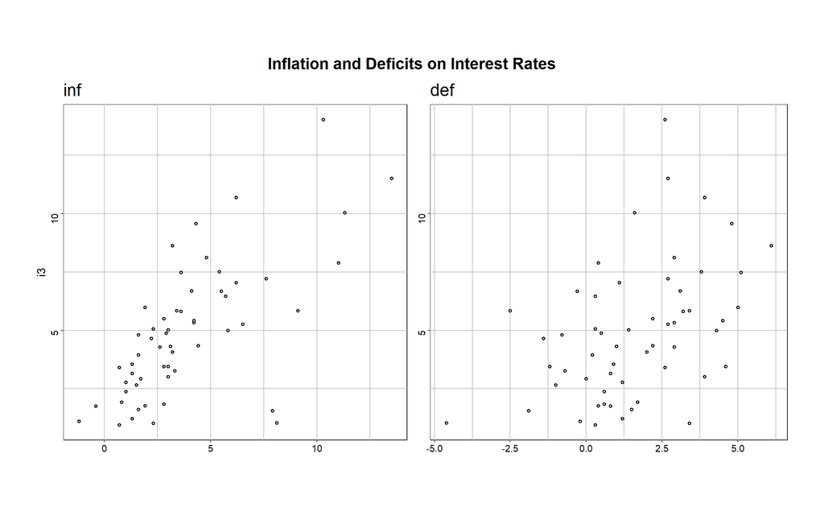

```r
RplotterPkg::multi_scatter_plot(
  df = intdef_dt,
  variables = c("inf", "def"),
  aes_y = "i3",
  col_width = 6,
  row_height = 6,
  title = "Inflation and Deficits on Interest Rates"
)
```

## 10.2 Time Series Data Types in R

### 10.2.1 Equispaced Time Series in R

1. Set up the data:

```r
data(barium, package = "wooldridge")
barium_dt <- data.table::setDT(barium)
barium_dt <- barium_dt[,.(chnimp)]
```

2. Create a time series (*ts*) object:

```r
imports_ts <- ts(data = barium_dt$chnimp, start = c(1978,2), frequency=12)
RtsaPkg::get_series_info(imports_ts)
```

```
## 'imports_ts' series is a ts object with:
##  Variables: 1
##  Observations: 131
##  Frequency: 12
##  Start time: 1978 2
##  End time: 1988 12
## 'imports_ts' Starting observations:
```

```
## [1] 220.4620  94.7980 219.3575 317.4215 114.6390
```

3. Plot the time series:

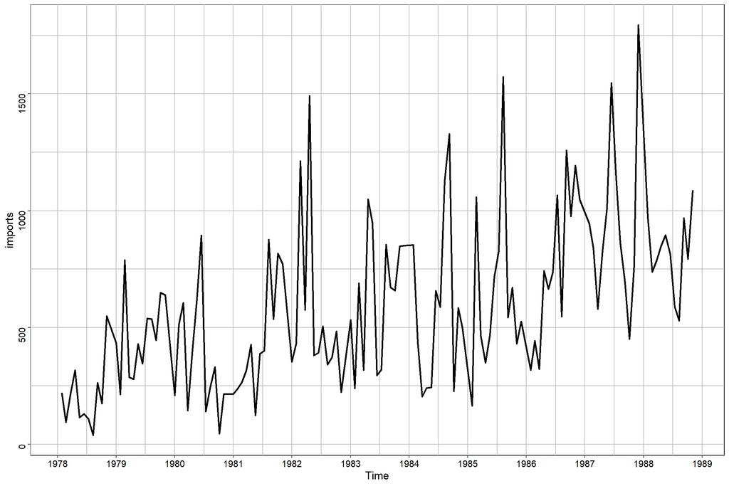

```r
imports_ts_df <- RtsaPkg::ts_to_df(imports_ts, col_name = "imports")
RplotterPkg::create_scatter_plot(
  df = imports_ts_df,
  aes_x = "DateTime",
  aes_y = "imports",
  x_major_date_breaks = "1 year",
  x_date_labels = "%Y",
  connect = T,
  show_pts = F,
  x_title = "Time"
)
```

### 10.2.2 Irregular Time Series in R

1. Create time series *zoo* object of the interest rate data:

```r
data("intdef", package = "wooldridge")
int_year_dt <- data.table::setDT(intdef)
int_year_dt <- int_year_dt[,.(i3, year)]

int_year_zoo <- zoo::zoo(int_year_dt, order.by = int_year_dt$year, frequency = 12)
RtsaPkg::get_series_info(series = int_year_zoo)
```

```
## 'int_year_zoo' series is a zoo object with:
##  Variables: 2
##  Observations: 56
##  Frequency: monthly
##  Start time: Jan 1948
##  End time: Jan 2003
## 'int_year_zoo' Starting observations:
```

```
##            i3 year
## Jan 1948 1.04 1948
## Jan 1949 1.10 1949
## Jan 1950 1.22 1950
## Jan 1951 1.55 1951
## Jan 1952 1.77 1952
```

2. Plot the interest across time:

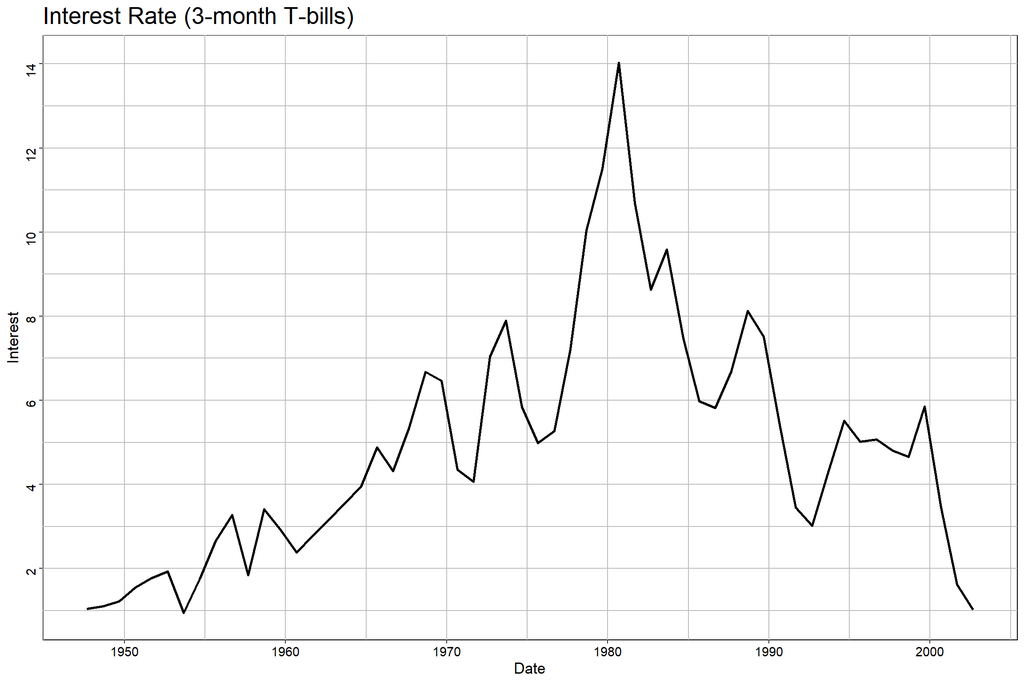

```r
int_year_zoo_df <- RtsaPkg::xts_to_df(int_year_zoo, col_names = c("Date", "Interest","Year"))
RplotterPkg::create_scatter_plot(
  df = int_year_zoo_df,
  aes_x = "Date",
  aes_y = "Interest",
  x_major_breaks = seq.Date(from = as.Date("1950", "%Y"), to = as.Date("2000", "%Y"), by = "10 year"),
  x_date_labels = "%Y",
  y_major_breaks = seq(2,14,2),
  connect = T,
  show_pts = F,
  title = "Interest Rate (3-month T-bills)"
)
```

Task: Plot closing prices on Apple stock from 2000 to latest year.

1. Use the *quantmod::* package to get the data from Yahoo as the source:

```r
apple_stocks_xts <- RtsaPkg::get_yahoo_stock_prices(
  symbols = "AAPL",
  from = "2000-01-01",
  to = "2021-01-01",
  periodicity = "daily",
  return_class = "xts"
)
RtsaPkg::get_series_info(series = apple_stocks_xts)
```

```
## 'apple_stocks_xts' series is a xts object with:
##  Variables: 6
##  Observations: 5284
##  Frequency: daily
##  Start time: 2000-01-03
##  End time: 2020-12-31
## 'apple_stocks_xts' Starting observations:
```

```
##            AAPL.Open AAPL.High AAPL.Low AAPL.Close AAPL.Volume AAPL.Adjusted
## 2000-01-03  0.936384  1.004464 0.907924   0.999442   535796800      0.860883
## 2000-01-04  0.966518  0.987723 0.903460   0.915179   512377600      0.788302
## 2000-01-05  0.926339  0.987165 0.919643   0.928571   778321600      0.799837
## 2000-01-06  0.947545  0.955357 0.848214   0.848214   767972800      0.730621
## 2000-01-07  0.861607  0.901786 0.852679   0.888393   460734400      0.765229
```

2. Plot the data:

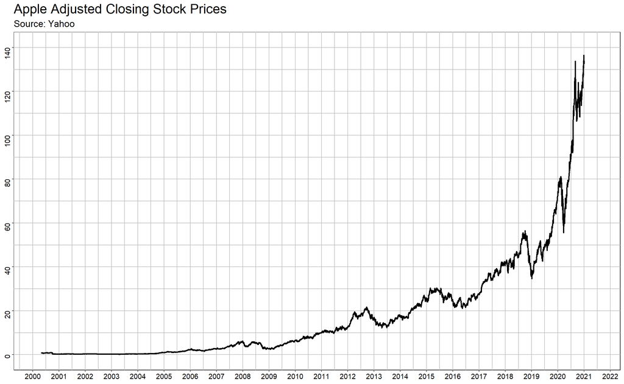

```r
apple_stocks_df <- RtsaPkg::xts_to_df(apple_stocks_xts)
RplotterPkg::create_scatter_plot(
  df = apple_stocks_df,
  aes_x = "index",
  aes_y = "AAPL.Adjusted",
  x_major_date_breaks = "1 year",
  x_date_labels = "%Y",
  x_limits = c(as.Date("2000", "%Y"), as.Date("2021", "%Y")),
  y_major_breaks = seq(0,140,20),
  y_limits = c(0,140),
  x_title = NULL,
  y_title = NULL,
  title = "Apple Adjusted Closing Stock Prices",
  subtitle = "Source: Yahoo",
  connect = T,
  show_pts = F
)
```

## 10.3 Other Time Series Models

### 10.3.1 The *dynlm::* Package

### 10.3.2 Finite Distributed Lag Models

Task: Model Effects of Personal Tax Exemption on Fertility Rates

1. Set up the data:

```r
data("fertil3", package = "wooldridge")
```

2. Define yearly time series beginning in 1913:

```r
fertil3_ts <- ts(fertil3, start = 1913)
RtsaPkg::get_series_info(fertil3_ts)
```

```
## 'fertil3_ts' series is a mts object with:
##  Variables: 24
##  Observations: 72
##  Frequency: 1
##  Start time: 1913 1
##  End time: 1984 1
## 'fertil3_ts' Starting observations:
```

```
##        gfr    pe year t tsq pe_1 pe_2 pe_3 pe_4 pill ww2 tcu      cgfr   cpe cpe_1 cpe_2 cpe_3 cpe_4 gfr_1    cgfr_1    cgfr_2   cgfr_3
## [1,] 124.7  0.00 1913 1   1   NA   NA   NA   NA    0   0   1        NA    NA    NA    NA    NA    NA    NA        NA        NA       NA
## [2,] 126.6  0.00 1914 2   4    0   NA   NA   NA    0   0   8  1.900002  0.00    NA    NA    NA    NA 124.7        NA        NA       NA
## [3,] 125.0  0.00 1915 3   9    0    0   NA   NA    0   0  27 -1.599998  0.00     0    NA    NA    NA 126.6  1.900002        NA       NA
## [4,] 123.4  0.00 1916 4  16    0    0    0   NA    0   0  64 -1.599998  0.00     0     0    NA    NA 125.0 -1.599998  1.900002       NA
## [5,] 121.0 19.27 1917 5  25    0    0    0    0    0   0 125 -2.400002 19.27     0     0     0    NA 123.4 -1.599998 -1.599998 1.900002
##      cgfr_4 gfr_2
## [1,]     NA    NA
## [2,]     NA    NA
## [3,]     NA 124.7
## [4,]     NA 126.6
## [5,]     NA 125.0
```

3. Define linear regression model with lags using *dynlm::dynlm()*:

```r
fertil_3_lm <- dynlm::dynlm(gfr ~ pe + L(pe) + L(pe,2) + ww2 + pill, data = fertil3_ts)
```

4. Summarize *fertil_3_lm*:

```r
summary(fertil_3_lm)
```

```
##
## Time series regression with "ts" data:
## Start = 1915, End = 1984
##
## Call:
## dynlm::dynlm(formula = gfr ~ pe + L(pe) + L(pe, 2) + ww2 + pill,
##     data = fertil3_ts)
##
## Residuals:
##      Min       1Q   Median       3Q      Max
## -24.6461  -9.5409  -0.0312   8.3378  29.1295
##
## Coefficients:
##              Estimate Std. Error t value Pr(>|t|)
## (Intercept)  95.87050    3.28196  29.211  < 2e-16 ***
## pe            0.07267    0.12553   0.579   0.5647
## L(pe)        -0.00578    0.15566  -0.037   0.9705
## L(pe, 2)      0.03383    0.12626   0.268   0.7896
## ww2         -22.12650   10.73197  -2.062   0.0433 *
## pill        -31.30499    3.98156  -7.862 5.63e-11 ***
## ---
## Signif. codes:  0 '***' 0.001 '**' 0.01 '*' 0.05 '.' 0.1 ' ' 1
##
## Residual standard error: 14.27 on 64 degrees of freedom
## Multiple R-squared:  0.4986, Adjusted R-squared:  0.4594
## F-statistic: 12.73 on 5 and 64 DF,  p-value: 1.353e-08
```

5. Perform an $F$-test with the null hypothesis that the lag coefficients equal zero:

```r
car::linearHypothesis(fertil_3_lm,c("pe", "L(pe)", "L(pe, 2)"))
```

```
## Linear hypothesis test
##
## Hypothesis:
## pe = 0
## L(pe) = 0
## L(pe, 2) = 0
##
## Model 1: restricted model
## Model 2: gfr ~ pe + L(pe) + L(pe, 2) + ww2 + pill
##
##   Res.Df   RSS Df Sum of Sq     F  Pr(>F)
## 1     67 15460
## 2     64 13033  3    2427.1 3.973 0.01165 *
## ---
## Signif. codes:  0 '***' 0.001 '**' 0.01 '*' 0.05 '.' 0.1 ' ' 1
```

Task: Repeat the OLS estimate by lagging the data and using *Rregress::ols_calc()*

1. Convert the data to a *data.table*:

```r
data("fertil3", package = "wooldridge")
fertil3_dt <- data.table::setDT(fertil3)
fertil3_dt <- fertil3_dt[, .(gfr, pe, ww2, pill)]
```

2. Lag the *pe* predictor by a factor of 2:

```r
fertil3_dt[, c("pe_lag1", "pe_lag2") := shift(pe, 1:2, type = "lag")]
fertil3_dt <- fertil3_dt[!is.na(pe_lag2)]
```

3. Compute the OLS:

```r
formula_obj <- gfr ~ pe + pe_lag1 + pe_lag2 + ww2 + pill
fertil3_ols <- RregressPkg::ols_calc(df = fertil3_dt, formula_obj = formula_obj)
```

4. Show the OLS coefficients:

```r
RplotterPkg::create_table(fertil3_ols$coef_df)
```

| Coef | Value | SE | t_value | p_Value |
| --- | --- | --- | --- | --- |
| (Intercept) | 95.870497467 | 3.2819571 | 29.21138071 | 1.022560e-38 |
| pe | 0.072671828 | 0.1255331 | 0.57890569 | 5.646848e-01 |
| pe_lag1 | -0.005779582 | 0.1556629 | -0.03712883 | 9.704979e-01 |
| pe_lag2 | 0.033826844 | 0.1262574 | 0.26791971 | 7.896227e-01 |
| ww2 | -22.126497512 | 10.7319716 | -2.06173649 | 4.329888e-02 |
| pill | -31.304988800 | 3.9815591 | -7.86249501 | 5.633695e-11 |

### 10.3.3 Trends

Task: Include a time predictor in estimating housing investment from prices.

1. Set up the data:

```r
data("hseinv", package = "wooldridge")
hseinv_dt <- data.table::setDT(hseinv)
hseinv_dt <- hseinv_dt[, .(invpc, year, price)]
```

2. Compute the OLS:

```r
formula_obj <- log(invpc) ~ year + log(price)
hseinv_ols <- RregressPkg::ols_calc(df = hseinv_dt, formula_obj = formula_obj)
RplotterPkg::create_table(hseinv_ols$coef_df)
```

| Coef | Value | SE | t_value | p_Value |
| --- | --- | --- | --- | --- |
| (Intercept) | -20.039759954 | 6.96452684 | -2.8774044 | 0.006471953 |
| year | 0.009828726 | 0.00351221 | 2.7984447 | 0.007939359 |
| log(price) | -0.380961330 | 0.67883522 | -0.5611985 | 0.577872803 |